# Understand Superpower Squad under 5 Minutes

[figure not shown]

## What is SuperPower Squad?

SuperPower Squad is a **Web3 fast-paced action shooter mobile game** built on the **BNB chain**.

SPS Players will play heroes with **unique abilities** to fight in **6 different game modes** with elements from **Battle Royale**, **MOBA** and **RPG**.

[figure not shown]

## Secret Weapons 🔫

- **In-App Purchase & Contract Wallets** 💳
- **Customizable UGC Metacube Tools** ✏️
- **Low Inflation & Burning System** 🔥
- **2 Years of Game Content, All Designed In-house** 👨‍🎨

### In-App Purchase & Contract Wallets 💳

[figure not shown]

Users can sign up wallet accounts with **emails** and purchase tokens directly with **app stores**

[figure not shown]

One email address can manage multiple devices (private keys)

*Details can be found: https://docs.ssquad.games/*

### UGC Metacube Tools ✏️

[figure not shown]

User-Generated-Content (UGC): Users use **Metacube** and **create NFT playmodes** with **SPS foundation** to **share** or **sell** for **profit**.

[figure not shown]

Similar to custom games in DOTA, users can **define rules**, **modify maps and assets**.

### Low Inflation & Burning System 🔥

[figure not shown]

### Low Inflation

- **PvP** rewards require:
  - Good skills 🍳
  - Good understanding of hero stats & abilities 📊
  - Trial & error with in-game asset 😃
    - ex. Battle Royale is designed to reward player to achieve **🔝 5 out of 12** to cover the cost of NFT heros.
- **PvE** rewards require:
  - $ECG entry ticket
  - Good performence to cover cost
- **UGC** profit requires:
  - Creative use of Metacube
  - Popularity

### Dual Token & Burning System

[figure not shown]

#### Addition Info on Tokenomics

[output not shown]

### Token Distribution Understood

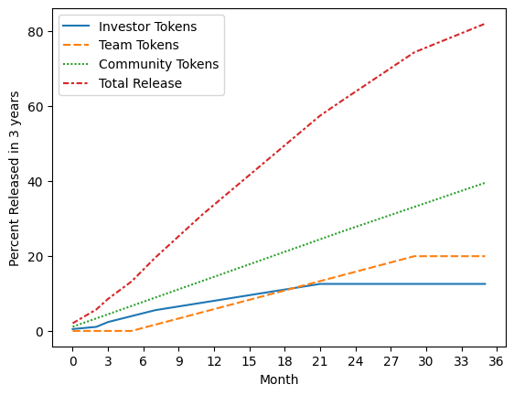

### All In-house Designed Content 👨‍🎨

[figure not shown]

- Developed for **3 years** by our **32-member game studio**
- 26 Unique **Heros** come with unique **Skins** and **Weapons**
- Unity Engine

Hero Catalog: https://docs.ssquad.games/gameplay/hero-system/tank  
In-game capture: https://youtu.be/2I3VtHuS0gw

# Thanks for Reading!

Find us at https://linktr.ee/Superpower.Squad

[figure not shown]